# Final Analysis

Joshua White

1 April 2019

## Load Packages and set seed for reproducibility

```r
library(tidyverse)
library(here)
library(car) # for recode function
library(ordinal) # for clmm (cumulative link mixed model) function for frequentist mixed models
library(MASS) # for Polr fucntion(proportional odds logistic regression) when no random effects (clmm doesn't work here)
library(brms)
library(skimr)

set.seed(1298)
```

## Import Data

```r
d <- read_csv("parsedrawresults.csv", col_types = "icffffnnfnfc")
d <- d[,2:12]
glimpse(d)
```

```
## Observations: 1,207
## Variables: 11
## $ subject             <chr> "o2lc35yzcpg", "7emt35yz8gy", "go6e35yzl0i...
## $ condition           <fct> L3A, L8B, L11B, G6A, L9B, L7A, L8B, G1B, L...
## $ vignetteType        <fct> L, L, L, G, L, L, L, G, L, G, G, L, L, G, ...
## $ vignetteNumber      <fct> 3, 8, 11, 6, 9, 7, 8, 1, 10, 4, 11, 2, 9, ...
## $ answerOrder         <fct> A, B, B, A, B, A, B, B, B, A, B, B, A, B, ...
## $ dummyVignetteAnswer <dbl> 7, 7, 7, 7, 7, 7, 7, 7, 7, 7, 7, 7, 7, 7, ...
## $ vignetteAnswer      <dbl> 2, 1, 6, 2, 4, 2, 4, 5, 6, 1, 6, 2, 4, 7, ...
## $ gender              <fct> male, female, male, female, female, male, ...
## $ age                 <dbl> 51, 35, 49, 24, 42, 75, 50, 35, 31, 42, 37...
## $ postquestion1       <fct> correct, correct, correct, correct, correc...
## $ postquestion2       <chr> "I prefer to know the specific odds", NA, ...
```

## Data Wrangling

#### Recode VignetteAnswer variable, create new variable, and reorder data

```r
d$vignetteAnswer[d$answerOrder == "A"] <- recode(d$vignetteAnswer[d$answerOrder == "A"], "1 = 3;
                                                                                          2 = 2;
                                                                                          3 = 1;
                                                                                          4 = 0;
                                                                                          5 = -1;
                                                                                          6 = -2;
                                                                                          7 = -3")

d$vignetteAnswer[d$answerOrder == "B"] <- recode(d$vignetteAnswer[d$answerOrder == "B"], "1 = -3;
                                                                                          2 = -2;
                                                                                          3 = -1;
                                                                                          4 = 0;
                                                                                          5 = 1;
                                                                                          6 = 2;
                                                                                          7 = 3")

###create new variable for vignette type + number -- vignette###
# order levels of factor for easy graphing
order <- c(sprintf("G%d", seq(1:12)), sprintf("L%d", seq(1:12)))
d$vignette <- paste0(d$vignetteType, d$vignetteNumber) %>% factor(levels = order)

#reorder data frame
d <- d[, c(1:5, 12, 6:11)]
```

## Instruction Checks

```r
# first remove amy's testing data point
amy.testing <- grep("amy", d$postquestion2)
d_amyremoved <- d[-amy.testing,]

#check whether observations fail instruction checks
instr_fail <- d_amyremoved$postquestion1 == "incorrect" | d_amyremoved$dummyVignetteAnswer <= 4

#remove data from main dataset and save for possible later analysis (was a particular question more confusing etc?)
d_removed <- d_amyremoved[instr_fail,]
d_pass <- d_amyremoved[!instr_fail,]

d_removed
```

```
## # A tibble: 76 x 12
##    subject condition vignetteType vignetteNumber answerOrder vignette
##    <chr>   <fct>     <fct>        <fct>          <fct>       <fct>
##  1 5fut35~ L9A       L            9              A           L9
##  2 nqn635~ L4A       L            4              A           L4
##  3 eif335~ G4A       G            4              A           G4
##  4 yfuw35~ G7A       G            7              A           G7
##  5 enz935~ L8A       L            8              A           L8
##  6 0yyy35~ G6B       G            6              B           G6
##  7 2utk35~ L9B       L            9              B           L9
##  8 nha635~ L8A       L            8              A           L8
##  9 bukf35~ G2A       G            2              A           G2
## 10 prhp35~ G3B       G            3              B           G3
## # ... with 66 more rows, and 6 more variables: dummyVignetteAnswer <dbl>,
## #   vignetteAnswer <dbl>, gender <fct>, age <dbl>, postquestion1 <fct>,
## #   postquestion2 <chr>
```

## Quickly Inspect Final Data

```r
skim(d_pass)
```

```
## Skim summary statistics
##  n obs: 1130
##  n variables: 12
##
## -- Variable type:character ------------------------------------------------------------------
##       variable missing complete    n min max empty n_unique
##  postquestion2     472      658 1130   6 693     0      653
##        subject       0     1130 1130  11  11     0     1127
##
## -- Variable type:factor ---------------------------------------------------------------------
##        variable missing complete    n n_unique
##     answerOrder       0     1130 1130        2
##       condition       0     1130 1130       48
##          gender       0     1130 1130        4
##   postquestion1       0     1130 1130        1
##        vignette       0     1130 1130       24
##  vignetteNumber       0     1130 1130       12
##    vignetteType       0     1130 1130        2
##                          top_counts ordered
##               B: 581, A: 549, NA: 0   FALSE
##  L8B: 36, L1A: 34, L5B: 33, L6B: 31   FALSE
##   fem: 578, mal: 549, oth: 2, na: 1   FALSE
##            cor: 1130, inc: 0, NA: 0   FALSE
##      L6: 62, L1: 59, L8: 58, G3: 56   FALSE
##       6: 111, 1: 108, 2: 105, 3: 99   FALSE
##               L: 584, G: 546, NA: 0   FALSE
##
## -- Variable type:numeric --------------------------------------------------------------------
##             variable missing complete    n  mean    sd p0 p25 p50 p75 p100
##                  age       0     1130 1130 40.06 11.06 18  32  38  47   75
##  dummyVignetteAnswer       0     1130 1130  6.92  0.32  5   7   7   7    7
##       vignetteAnswer       0     1130 1130  0.53  1.59 -3   0   0   2    3
##      hist
##  ▂▆▇▆▃▂▁▁
##  ▁▁▁▁▁▁▁▇
##  ▁▂▂▇▁▃▅▃
```

## Graph responses

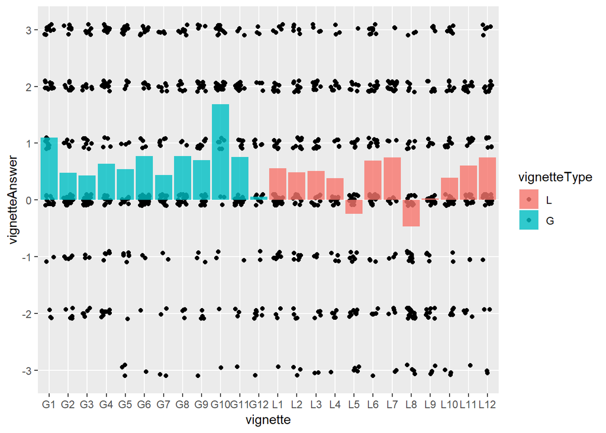

```r
#make plot
ggplot(d_pass, aes(x = vignette, y = vignetteAnswer, fill = vignetteType)) +
  geom_jitter(width = 0.25, height = 0.10) +
  stat_summary(fun.y=mean, geom="bar", alpha = 0.8) +
  scale_y_continuous(breaks = -3:3, minor_breaks = NULL, limits = (c(-3.10,3.10)))
```

## Data analysis: Fit ordinal logistic regression models

First, make vignetteAnswer an ordered factor

```r
d_pass$vignetteAnswer.ordfac <- ordered(d_pass$vignetteAnswer, levels = c("-3", "-2", "-1", "0", "1", "2", "3"))
```

### Frequentist

```r
olm.freq.nopred <-  polr(vignetteAnswer.ordfac ~ 1, data = d_pass, method = "logistic", Hess = TRUE)
olm.freq.GLpred <-  polr(vignetteAnswer.ordfac ~ vignetteType, data = d_pass, method = "logistic", Hess = TRUE)
olm.freq.ordpred <- polr(vignetteAnswer.ordfac ~ answerOrder, data = d_pass, method = "logistic", Hess = TRUE)
olmm.freq <-  clmm(vignetteAnswer.ordfac ~ vignetteType + (1|vignette), data = d_pass, link = "logit", nAGQ = 10) #values between 5 and 10 generally provide accurate maximum likelihood estimates -- documentation

summary(olm.freq.nopred)
```

```
## Call:
## polr(formula = vignetteAnswer.ordfac ~ 1, data = d_pass, Hess = TRUE,
##     method = "logistic")
##
## No coefficients
##
## Intercepts:
##       Value   Std. Error t value
## -3|-2  -3.358   0.165    -20.348
## -2|-1  -1.862   0.087    -21.352
## -1|0   -1.332   0.073    -18.199
## 0|1     0.142   0.060      2.378
## 1|2     0.716   0.063     11.298
## 2|3     2.058   0.094     21.921
##
## Residual Deviance: 3961.75
## AIC: 3973.75
```

```r
summary(olm.freq.GLpred)
```

```
## Call:
## polr(formula = vignetteAnswer.ordfac ~ vignetteType, data = d_pass,
##     Hess = TRUE, method = "logistic")
##
## Coefficients:
##               Value Std. Error t value
## vignetteTypeG 0.361      0.106     3.4
##
## Intercepts:
##       Value   Std. Error t value
## -3|-2  -3.197   0.171    -18.668
## -2|-1  -1.696   0.099    -17.051
## -1|0   -1.162   0.088    -13.189
## 0|1     0.319   0.080      4.013
## 1|2     0.895   0.083     10.796
## 2|3     2.242   0.109     20.530
##
## Residual Deviance: 3950.19
## AIC: 3964.19
```

```r
summary(olm.freq.ordpred)
```

```
## Call:
## polr(formula = vignetteAnswer.ordfac ~ answerOrder, data = d_pass,
##     Hess = TRUE, method = "logistic")
##
## Coefficients:
##               Value Std. Error t value
## answerOrderB -0.076      0.106  -0.719
##
## Intercepts:
##       Value   Std. Error t value
## -3|-2  -3.398   0.174    -19.512
## -2|-1  -1.901   0.103    -18.389
## -1|0   -1.371   0.092    -14.944
## 0|1     0.103   0.081      1.270
## 1|2     0.677   0.083      8.125
## 2|3     2.019   0.108     18.716
##
## Residual Deviance: 3961.24
## AIC: 3975.24
```

```r
summary(olmm.freq)
```

```
## Cumulative Link Mixed Model fitted with the adaptive Gauss-Hermite
## quadrature approximation with 10 quadrature points
##
## formula: vignetteAnswer.ordfac ~ vignetteType + (1 | vignette)
## data:    d_pass
##
##  link  threshold nobs logLik   AIC     niter     max.grad cond.H
##  logit flexible  1130 -1963.78 3943.56 633(1902) 3.24e-03 1.4e+02
##
## Random effects:
##  Groups   Name        Variance Std.Dev.
##  vignette (Intercept) 0.143    0.378
## Number of groups:  vignette 24
##
## Coefficients:
##               Estimate Std. Error z value Pr(>|z|)
## vignetteTypeG    0.366      0.188    1.94    0.052 .
## ---
## Signif. codes:  0 '***' 0.001 '**' 0.01 '*' 0.05 '.' 0.1 ' ' 1
##
## Threshold coefficients:
##       Estimate Std. Error z value
## -3|-2   -3.270      0.204  -16.00
## -2|-1   -1.749      0.149  -11.75
## -1|0    -1.202      0.141   -8.50
## 0|1      0.328      0.136    2.41
## 1|2      0.923      0.138    6.70
## 2|3      2.303      0.156   14.78
```

#### AIC values

The AIC values for our four different frequentist models are:

- 3973.75 for the model with no predictors
- 3964.19 for the model with Gain or Loss as a predictor
- 3975.24 for the model with answer order as a predictor
- 3943.56 for the mixed model with Gain or Loss and a random effect for vignette as predictors

Therefore, the most effective model is the mixed model, showing that there particpant ambiguity aversion is predicted both by whether the vignette was about a gain or a loss, and a random effect for vignette. The model taking into account answer order as a predictor had the worst Akaike Information Criterion, providing evidence that answer order did not effect participant responses.

### Bayesian

```r
olm.bayes.nopred <-  brm(vignetteAnswer.ordfac ~ 1, data = d_pass, family = cumulative(link = "logit"),
                         refresh = 0, open_progress = FALSE)  #to suppress progress printing to screen for .Rmd
olm.bayes.GLpred <-  brm(vignetteAnswer.ordfac ~ vignetteType, data = d_pass, family = cumulative(link = "logit"),
                         refresh = 0, open_progress = FALSE)
olm.bayes.ordpred <- brm(vignetteAnswer.ordfac ~ answerOrder, data = d_pass, family = cumulative(link = "logit"),
                         refresh = 0, open_progress = FALSE)
```

```
## recompiling to avoid crashing R session
```

```r
olmm.bayes <- brm(vignetteAnswer.ordfac ~ vignetteType + (1|vignette), data = d_pass, family = cumulative(link = "logit"),
                  refresh = 0, open_progress = FALSE)
summary(olm.bayes.nopred)
```

```
##  Family: cumulative
##   Links: mu = logit; disc = identity
## Formula: vignetteAnswer.ordfac ~ 1
##    Data: d_pass (Number of observations: 1130)
## Samples: 4 chains, each with iter = 2000; warmup = 1000; thin = 1;
##          total post-warmup samples = 4000
##
## Population-Level Effects:
##              Estimate Est.Error l-95% CI u-95% CI Eff.Sample Rhat
## Intercept[1]    -3.38      0.17    -3.71    -3.08       2132 1.00
## Intercept[2]    -1.87      0.09    -2.04    -1.71       4481 1.00
## Intercept[3]    -1.33      0.07    -1.48    -1.19       4409 1.00
## Intercept[4]     0.14      0.06     0.02     0.26       4040 1.00
## Intercept[5]     0.72      0.06     0.59     0.84       3569 1.00
## Intercept[6]     2.06      0.09     1.88     2.25       3833 1.00
##
## Samples were drawn using sampling(NUTS). For each parameter, Eff.Sample
## is a crude measure of effective sample size, and Rhat is the potential
## scale reduction factor on split chains (at convergence, Rhat = 1).
```

```r
summary(olm.bayes.GLpred)
```

```
##  Family: cumulative
##   Links: mu = logit; disc = identity
## Formula: vignetteAnswer.ordfac ~ vignetteType
##    Data: d_pass (Number of observations: 1130)
## Samples: 4 chains, each with iter = 2000; warmup = 1000; thin = 1;
##          total post-warmup samples = 4000
##
## Population-Level Effects:
##               Estimate Est.Error l-95% CI u-95% CI Eff.Sample Rhat
## Intercept[1]     -3.22      0.17    -3.56    -2.90       1975 1.00
## Intercept[2]     -1.70      0.10    -1.90    -1.51       4705 1.00
## Intercept[3]     -1.17      0.09    -1.33    -0.99       4540 1.00
## Intercept[4]      0.32      0.08     0.16     0.48       4270 1.00
## Intercept[5]      0.90      0.08     0.74     1.07       4519 1.00
## Intercept[6]      2.25      0.11     2.03     2.47       3839 1.00
## vignetteTypeG     0.36      0.11     0.15     0.57       4579 1.00
##
## Samples were drawn using sampling(NUTS). For each parameter, Eff.Sample
## is a crude measure of effective sample size, and Rhat is the potential
## scale reduction factor on split chains (at convergence, Rhat = 1).
```

```r
summary(olm.bayes.ordpred)
```

```
##  Family: cumulative
##   Links: mu = logit; disc = identity
## Formula: vignetteAnswer.ordfac ~ answerOrder
##    Data: d_pass (Number of observations: 1130)
## Samples: 4 chains, each with iter = 2000; warmup = 1000; thin = 1;
##          total post-warmup samples = 4000
##
## Population-Level Effects:
##              Estimate Est.Error l-95% CI u-95% CI Eff.Sample Rhat
## Intercept[1]    -3.42      0.18    -3.78    -3.09       2686 1.00
## Intercept[2]    -1.91      0.10    -2.11    -1.71       5095 1.00
## Intercept[3]    -1.37      0.09    -1.56    -1.20       4674 1.00
## Intercept[4]     0.10      0.08    -0.06     0.26       4688 1.00
## Intercept[5]     0.68      0.08     0.52     0.84       4822 1.00
## Intercept[6]     2.03      0.11     1.82     2.25       5191 1.00
## answerOrderB    -0.08      0.11    -0.28     0.13       5252 1.00
##
## Samples were drawn using sampling(NUTS). For each parameter, Eff.Sample
## is a crude measure of effective sample size, and Rhat is the potential
## scale reduction factor on split chains (at convergence, Rhat = 1).
```

```r
summary(olmm.bayes)
```

```
##  Family: cumulative
##   Links: mu = logit; disc = identity
## Formula: vignetteAnswer.ordfac ~ vignetteType + (1 | vignette)
##    Data: d_pass (Number of observations: 1130)
## Samples: 4 chains, each with iter = 2000; warmup = 1000; thin = 1;
##          total post-warmup samples = 4000
##
## Group-Level Effects:
## ~vignette (Number of levels: 24)
##               Estimate Est.Error l-95% CI u-95% CI Eff.Sample Rhat
## sd(Intercept)     0.43      0.10     0.27     0.65       1400 1.00
##
## Population-Level Effects:
##               Estimate Est.Error l-95% CI u-95% CI Eff.Sample Rhat
## Intercept[1]     -3.29      0.21    -3.71    -2.89       1853 1.00
## Intercept[2]     -1.75      0.16    -2.07    -1.45       1597 1.00
## Intercept[3]     -1.20      0.15    -1.50    -0.90       1556 1.00
## Intercept[4]      0.34      0.15     0.06     0.63       1424 1.00
## Intercept[5]      0.94      0.15     0.65     1.23       1451 1.00
## Intercept[6]      2.32      0.17     2.00     2.66       1614 1.00
## vignetteTypeG     0.38      0.21    -0.04     0.78       1365 1.00
##
## Samples were drawn using sampling(NUTS). For each parameter, Eff.Sample
## is a crude measure of effective sample size, and Rhat is the potential
## scale reduction factor on split chains (at convergence, Rhat = 1).
```

#### WAIC values

The WAIC values for our four different Bayesian models are (I was not able to easily extract the AIC from these models):

- 3973.7 for the model with no predictors
- 3964.32 for the model with Gain or Loss as a predictor
- 3975.36 for the model with answer order as a predictor
- 3929.29 for the mixed model with Gain or Loss and a random effect for vignette as predictors

Therefore, the most effective model is the mixed model, showing that there particpant ambiguity aversion is predicted both by whether the vignette was about a gain or a loss, and a random effect for vignette. The model taking into account answer order as a predictor had the worst WAIC, providing evidence that answer order did not effect participant responses.

## Urn Analysis

### Plot

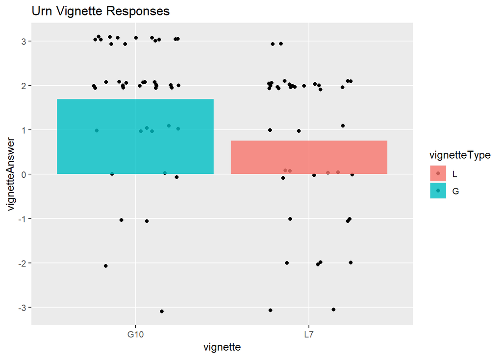

```r
##filter dataset to contain only urn vignettes
d_pass_urns <- d_pass %>% filter(vignette == "G10" | vignette == "L7")

##plot
ggplot(d_pass_urns, aes(x = vignette, y = vignetteAnswer, fill = vignetteType)) +
  geom_jitter(width = 0.25, height = 0.10) +
  stat_summary(fun.y=mean, geom="bar", alpha = 0.8) +
  scale_y_continuous(breaks = -3:3, minor_breaks = NULL, limits = (c(-3.10,3.10))) +
  ggtitle("Urn Vignette Responses")
```

### Statistical analyses

#### Frequentist

```r
olm.freq.nopred.urns <-  polr(vignetteAnswer.ordfac ~ 1, data = d_pass_urns,
                              method = "logistic", Hess = TRUE)
olm.freq.GLpred.urns <-  polr(vignetteAnswer.ordfac ~ vignetteType, data = d_pass_urns,
                              method = "logistic", Hess = TRUE)

summary(olm.freq.nopred.urns)
```

```
## Call:
## polr(formula = vignetteAnswer.ordfac ~ 1, data = d_pass_urns,
##     Hess = TRUE, method = "logistic")
##
## No coefficients
##
## Intercepts:
##       Value Std. Error t value
## -3|-2 -3.31  0.59      -5.63
## -2|-1 -2.26  0.37      -6.10
## -1|0  -1.71  0.30      -5.68
## 0|1   -0.99  0.24      -4.06
## 1|2   -0.50  0.22      -2.25
## 2|3    1.54  0.28       5.41
##
## Residual Deviance: 273.17
## AIC: 285.17
```

```r
summary(olm.freq.GLpred.urns)
```

```
## Call:
## polr(formula = vignetteAnswer.ordfac ~ vignetteType, data = d_pass_urns,
##     Hess = TRUE, method = "logistic")
##
## Coefficients:
##               Value Std. Error t value
## vignetteTypeG   1.2      0.417    2.87
##
## Intercepts:
##       Value  Std. Error t value
## -3|-2 -2.839  0.607     -4.680
## -2|-1 -1.775  0.404     -4.395
## -1|0  -1.203  0.344     -3.491
## 0|1   -0.440  0.307     -1.436
## 1|2    0.075  0.299      0.249
## 2|3    2.261  0.395      5.726
##
## Residual Deviance: 264.55
## AIC: 278.55
```

#### AIC values

The AIC values for our two different frequentist models are:

- 285.17 for the model with no predictors
- 278.55 for the model with Gain or Loss as a predictor

These values illustrate that the existing effect is replicated in our findings. Firstly, ambiguity aversion exists in both gains and loss variants of the classic urn task. Secondly, the degree of ambiguity aversion is affected by whether we are discussing domains of loss or gain — ambiguity aversion is stronger for gains than for losses.

#### Bayesian

```r
olm.bayes.nopred.urns <- brm(vignetteAnswer.ordfac ~ 1, data = d_pass_urns, family = cumulative(link = "logit"),
                         refresh = 0, open_progress = FALSE)  #to suppress progress printing to screen for .Rmd
```

```
## recompiling to avoid crashing R session
```

```r
olm.bayes.GLpred.urns <- brm(vignetteAnswer.ordfac ~ vignetteType, data = d_pass_urns, family = cumulative(link = "logit"),
                         refresh = 0, open_progress = FALSE)
```

```
## recompiling to avoid crashing R session
```

```r
summary(olm.bayes.nopred.urns)
```

```
##  Family: cumulative
##   Links: mu = logit; disc = identity
## Formula: vignetteAnswer.ordfac ~ 1
##    Data: d_pass_urns (Number of observations: 85)
## Samples: 4 chains, each with iter = 2000; warmup = 1000; thin = 1;
##          total post-warmup samples = 4000
##
## Population-Level Effects:
##              Estimate Est.Error l-95% CI u-95% CI Eff.Sample Rhat
## Intercept[1]    -3.71      0.63    -5.05    -2.62       2095 1.00
## Intercept[2]    -2.45      0.39    -3.31    -1.75       3066 1.00
## Intercept[3]    -1.80      0.31    -2.43    -1.22       3945 1.00
## Intercept[4]    -1.02      0.25    -1.51    -0.55       3794 1.00
## Intercept[5]    -0.49      0.22    -0.94    -0.06       3788 1.00
## Intercept[6]     1.59      0.28     1.06     2.16       4295 1.00
##
## Samples were drawn using sampling(NUTS). For each parameter, Eff.Sample
## is a crude measure of effective sample size, and Rhat is the potential
## scale reduction factor on split chains (at convergence, Rhat = 1).
```

```r
summary(olm.bayes.GLpred.urns)
```

```
##  Family: cumulative
##   Links: mu = logit; disc = identity
## Formula: vignetteAnswer.ordfac ~ vignetteType
##    Data: d_pass_urns (Number of observations: 85)
## Samples: 4 chains, each with iter = 2000; warmup = 1000; thin = 1;
##          total post-warmup samples = 4000
##
## Population-Level Effects:
##               Estimate Est.Error l-95% CI u-95% CI Eff.Sample Rhat
## Intercept[1]     -3.22      0.67    -4.74    -2.06       1867 1.00
## Intercept[2]     -1.92      0.42    -2.79    -1.14       4453 1.00
## Intercept[3]     -1.26      0.36    -1.99    -0.56       5007 1.00
## Intercept[4]     -0.44      0.31    -1.06     0.17       5353 1.00
## Intercept[5]      0.11      0.31    -0.50     0.74       4689 1.00
## Intercept[6]      2.34      0.40     1.59     3.16       3902 1.00
## vignetteTypeG     1.25      0.43     0.43     2.12       4028 1.00
##
## Samples were drawn using sampling(NUTS). For each parameter, Eff.Sample
## is a crude measure of effective sample size, and Rhat is the potential
## scale reduction factor on split chains (at convergence, Rhat = 1).
```

#### WAIC values

- 285.3 for the model with no predictors
- 279.55 for the model with Gain or Loss as a predictor

These values illustrate that the existing effect is replicated in our findings. Firstly, ambiguity aversion exists in both gains and loss variants of the classic urn task. Secondly, the degree of ambiguity aversion is affected by whether we are discussing domains of loss or gain — ambiguity aversion is stronger for gains than for losses.